# Homework 5

Feyyaz Şentürk

6 Ocak 2019

# Task

My first task is to use a clustering algorithm to determine the clusters. I have tried k-medioids and hierarchical clustering with euclidean and manhattan distance measures. For hierarchical, I also checked the performance of complete and single linkage. Determination is done by calculating the within sum of squares (WSS) for each clustering and then checking the plot of WSS versus cluster numbers and select where the biggest drop happens. Then compare the best of each method to find out the final method.

```r
library(cluster)
library(data.table)
library(glmnet)
library(TunePareto)
library(ROCR)
source("Lasso.R")
set.seed(500)



data<-read.csv("Musk1.csv",header=FALSE)
colnames(data)[1:2] <- c("Bag_Class","Bag_Id")
data[,c(3:168)]<-scale(data[,c(3:168)])

#Calculating of WSS
wss<-function(d) {
  sum(scale(d, scale = FALSE)^2)
}




##Euclidean
k=c(1:20)
param_dat_euc=data.frame(0,ncol=2)
colnames(param_dat_euc)<-list("k value","   WSS")

for(i in 1:length(k)){
  temp<-0
  temp2<-0
  result<-pam(data[,-c(1:2)],k[i],metric="euclidean")

  spl <- split(data[,-c(1:2)], result$clustering)



  temp<-sum(sapply(spl, wss))
  temp2<-c(k[i],temp)
  param_dat_euc<-rbind(param_dat_euc,temp2)
}

param_dat_euc<-param_dat_euc[-1,]
param_dat_euc
```

```
##    k value      WSS
## 2        1 78850.00
## 3        2 57232.13
## 4        3 54107.40
## 5        4 45321.88
## 6        5 43768.01
## 7        6 41043.48
## 8        7 39820.95
## 9        8 38655.33
## 10       9 37258.15
## 11      10 35909.35
## 12      11 34442.63
## 13      12 33245.26
## 14      13 32490.81
## 15      14 31866.09
## 16      15 31035.12
## 17      16 30641.72
## 18      17 30267.06
## 19      18 29572.62
## 20      19 29131.21
## 21      20 28689.12
```

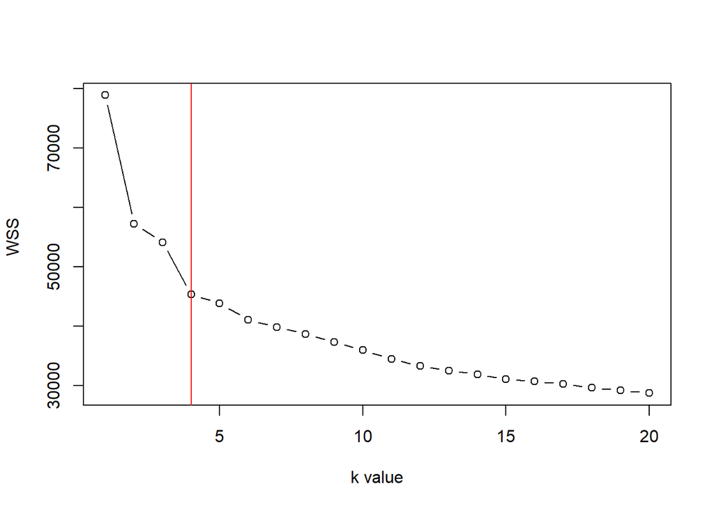

```
## integer(0)
```

```r
plot.new()
plot(param_dat_euc,type="b")+
abline(v=4,col="red")
```

```r
result<-pam(data[,-c(1:2)],4,metric="euclidean")
spl <- split(data[,-c(1:2)], result$clustering)
k_euc_best<-sum(sapply(spl, wss))

k_euc_best
```

```
## [1] 45321.88
```

```r
##Manhattan
k=c(1:20)
param_dat_man=data.frame(0,ncol=2)
colnames(param_dat_man)<-list("k value","   WSS")

for(i in 1:length(k)){
  temp<-0
  temp2<-0
  result<-pam(data[,-c(1:2)],k[i],metric="manhattan")

  spl <- split(data[,-c(1:2)], result$clustering)



  temp<-sum(sapply(spl, wss))
  temp2<-c(k[i],temp)

  param_dat_man<-rbind(param_dat_man,temp2)
}

param_dat_man<-param_dat_man[-1,]
param_dat_man
```

```
##    k value      WSS
## 2        1 78850.00
## 3        2 57477.77
## 4        3 48814.96
## 5        4 46682.79
## 6        5 45159.62
## 7        6 42036.02
## 8        7 40187.09
## 9        8 39032.47
## 10       9 37989.93
## 11      10 36514.54
## 12      11 34587.74
## 13      12 33932.96
## 14      13 33718.72
## 15      14 32870.77
## 16      15 32276.07
## 17      16 31723.01
## 18      17 31342.40
## 19      18 30884.51
## 20      19 30574.12
## 21      20 30147.86
```

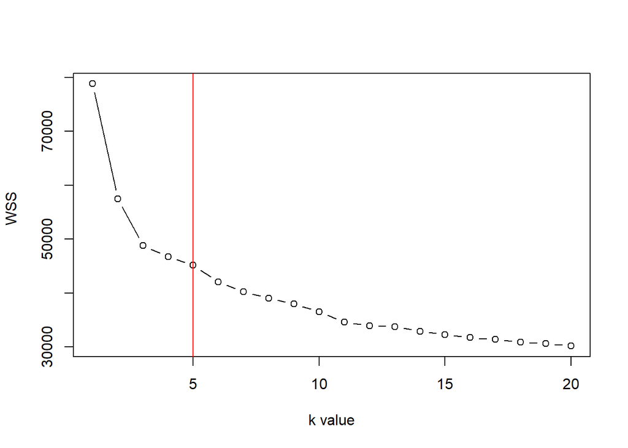

```
## integer(0)
```

```r
plot(param_dat_man,type="b")+
abline(v=5,col="red")
```

```r
result<-pam(data[,-c(1:2)],5,metric="manhattan")

spl <- split(data[,-c(1:2)], result$clustering)



k_man_best<-sum(sapply(spl, wss))

k_man_best
```

```
## [1] 45159.62
```

```r
#Hierarchical Clustering
##Euclidean
##Single Linkage
dist_euc<-dist(data[,-c(1:2)],method = "euclidean")

hclust_euc<-hclust(dist_euc,method="single")

hclus_dat_e1<-data.frame(0,ncol=2)
colnames(hclus_dat_e1)<-list("k value","  WSS")

k=c(1:20)
for(i in 1:length(k)){
  temp<-0
  temp2<-0

  cl <- cutree(hclust_euc, k[i])
  spl <- split(data[,-c(1:2)], cl)


  temp<-sum(sapply(spl, wss))
  temp2<-c(k[i],temp)

  hclus_dat_e1<-rbind(hclus_dat_e1,temp2)
}


hclus_dat_e1<-hclus_dat_e1[-1,]
hclus_dat_e1
```

```
##    k value      WSS
## 2        1 78850.00
## 3        2 77452.11
## 4        3 76968.03
## 5        4 76594.14
## 6        5 76206.75
## 7        6 75824.45
## 8        7 75522.84
## 9        8 75091.72
## 10       9 74783.69
## 11      10 74433.26
## 12      11 73210.08
## 13      12 71618.76
## 14      13 69773.67
## 15      14 69427.12
## 16      15 69097.71
## 17      16 66095.25
## 18      17 65925.45
## 19      18 65767.87
## 20      19 65204.59
## 21      20 64914.50
```

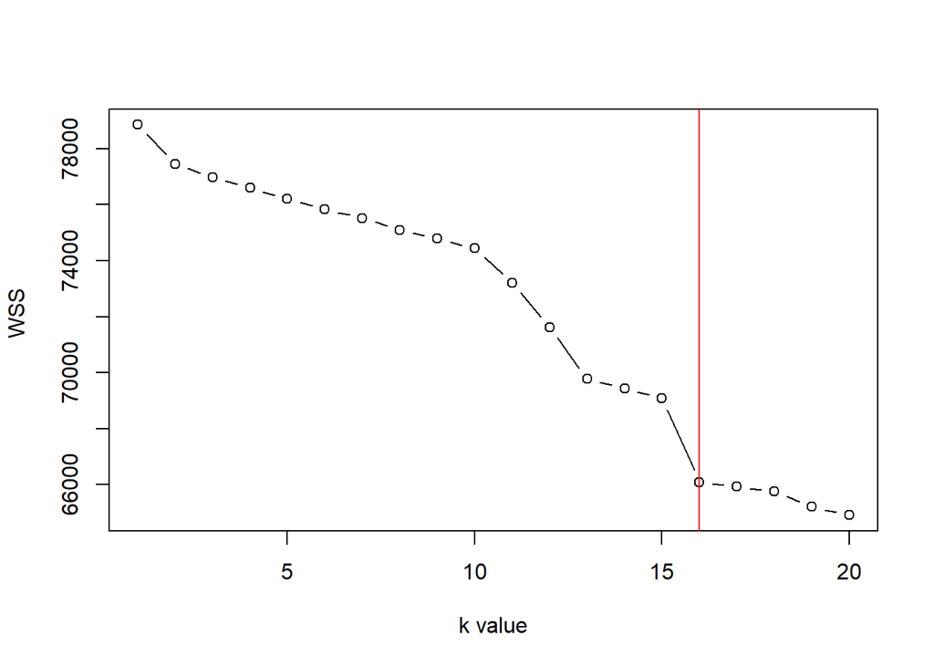

```
## integer(0)
```

```r
plot(hclus_dat_e1,type="b") + abline(v=16,col="red")
```

```r
cl <- cutree(hclust_euc, 16)
spl <- split(data[,-c(1:2)], cl)


hier_euc_single_best<-sum(sapply(spl, wss))
hier_euc_single_best
```

```
## [1] 66095.25
```

```r
##Complete Linkage

hclust_euc<-hclust(dist_euc,method="complete")

hclus_dat_e2<-data.frame(0,ncol=2)
colnames(hclus_dat_e2)<-list("k value","   WSS")

k=c(1:20)
for(i in 1:length(k)){
  temp<-0
  temp2<-0

  cl <- cutree(hclust_euc, k[i])
  spl <- split(data[,-c(1:2)], cl)


  temp<-sum(sapply(spl, wss))
  temp2<-c(k[i],temp)

  hclus_dat_e2<-rbind(hclus_dat_e2,temp2)
}


hclus_dat_e2<-hclus_dat_e2[-1,]
hclus_dat_e2
```

```
##    k value      WSS
## 2        1 78850.00
## 3        2 74550.56
## 4        3 54498.71
## 5        4 53610.68
## 6        5 46139.41
## 7        6 45519.31
## 8        7 45095.78
## 9        8 44185.93
## 10       9 42027.37
## 11      10 40141.73
## 12      11 38967.18
## 13      12 38356.82
## 14      13 37722.25
## 15      14 37514.49
## 16      15 36360.28
## 17      16 36157.93
## 18      17 34374.24
## 19      18 33754.98
## 20      19 32483.12
## 21      20 32016.81
```

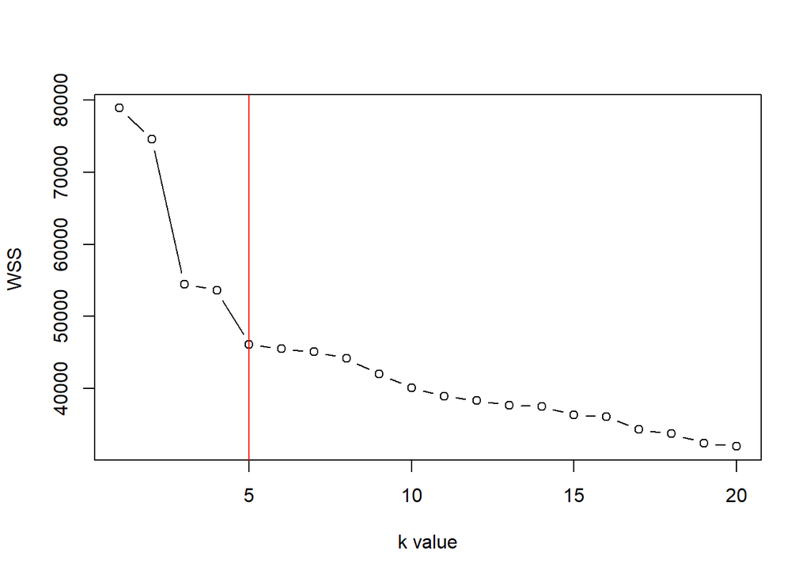

```
## integer(0)
```

```r
plot(hclus_dat_e2,type="b")+abline(v=5,col="red")
```

```r
cl <- cutree(hclust_euc, 5)
spl <- split(data[,-c(1:2)], cl)


hier_euc_complete_best<-sum(sapply(spl, wss))
hier_euc_complete_best
```

```
## [1] 46139.41
```

```r
##Manhattan
##Single

dist_man<-dist(data[,-c(1:2)],method = "manhattan")

hclust_man<-hclust(dist_man,method="single")

hclus_dat_m1<-data.frame(0,ncol=2)
colnames(hclus_dat_m1)<-list("k value","   WSS")

k=c(1:20)
for(i in 1:length(k)){
  temp<-0
  temp2<-0

  cl <- cutree(hclust_man, k[i])
  spl <- split(data[,-c(1:2)], cl)


  temp<-sum(sapply(spl, wss))
  temp2<-c(k[i],temp)

  hclus_dat_m1<-rbind(hclus_dat_m1,temp2)
}


hclus_dat_m1<-hclus_dat_m1[-1,]
hclus_dat_m1
```

```
##    k value      WSS
## 2        1 78850.00
## 3        2 77452.11
## 4        3 77102.63
## 5        4 74000.42
## 6        5 73445.01
## 7        6 71596.14
## 8        7 71487.47
## 9        8 71151.80
## 10       9 70864.02
## 11      10 70447.14
## 12      11 70100.27
## 13      12 69720.75
## 14      13 68071.37
## 15      14 67573.52
## 16      15 67076.90
## 17      16 61771.55
## 18      17 61621.76
## 19      18 61198.30
## 20      19 60364.02
## 21      20 59992.19
```

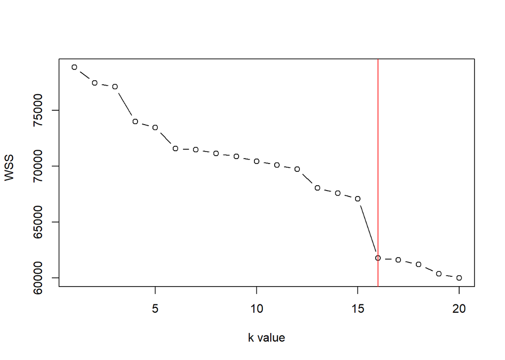

```
## integer(0)
```

```r
plot(hclus_dat_m1,type="b")+abline(v=16,col="red")
```

```r
cl <- cutree(hclust_man, 16)
spl <- split(data[,-c(1:2)], cl)


hier_man_single_best<-sum(sapply(spl, wss))
hier_man_single_best
```

```
## [1] 61771.55
```

```r
##Complete


hclust_man<-hclust(dist_man,method="complete")

hclus_dat_m2<-data.frame(0,ncol=2)
colnames(hclus_dat_m2)<-list("k value","   WSS")

k=c(1:20)
for(i in 1:length(k)){
  temp<-0
  temp2<-0

  cl <- cutree(hclust_man, k[i])
  spl <- split(data[,-c(1:2)], cl)


  temp<-sum(sapply(spl, wss))
  temp2<-c(k[i],temp)

  hclus_dat_m2<-rbind(hclus_dat_m2,temp2)
}


hclus_dat_m2<-hclus_dat_m2[-1,]
hclus_dat_m2
```

```
##    k value      WSS
## 2        1 78850.00
## 3        2 74467.49
## 4        3 54016.11
## 5        4 46091.32
## 6        5 44805.42
## 7        6 43909.09
## 8        7 41966.35
## 9        8 41335.83
## 10       9 40455.66
## 11      10 39606.33
## 12      11 38742.52
## 13      12 36995.73
## 14      13 35071.92
## 15      14 34579.11
## 16      15 34196.35
## 17      16 33451.77
## 18      17 33130.05
## 19      18 32868.67
## 20      19 32509.88
## 21      20 31413.99
```

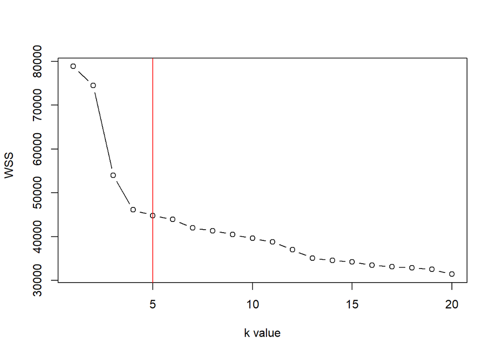

```
## integer(0)
```

```r
plot(hclus_dat_m2,type="b")+abline(v=5,col="red")
```

```r
cl <- cutree(hclust_man, 5)
spl <- split(data[,-c(1:2)], cl)


hier_man_complete_best<-sum(sapply(spl, wss))
hier_man_complete_best
```

```
## [1] 44805.42
```

```r
hier_man_single_best
```

```
## [1] 61771.55
```

```r
hier_euc_complete_best
```

```
## [1] 46139.41
```

```r
hier_euc_single_best
```

```
## [1] 66095.25
```

```r
k_man_best
```

```
## [1] 45159.62
```

```r
k_euc_best
```

```
## [1] 45321.88
```

```r
#Based on the results, hierarchical clust. with complete linkage,manhattan and 5 clusters is the best one
```

Based on the results, hierarchical clustering with complete linkage,manhattan distance measure and 5 clusters came out to be the best one. So, I calculated first the medioids of the 5 clusters and then calculated the manhattan distance of each data value from the medioids. By averaging these to groups, I came up with a new feature data that I trained using Lasso logistic regression.Also, before applying Lasso, I scaled the data one more time.

```r
final_model<- cutree( (hclust(dist_man,method="complete")),5)

spl <- split(data[,-c(1:2)], final_model)

medioids<-sapply(spl,colMeans)

medioids<-t(medioids)
features<-NULL

for(i in 1:nrow(data)){
  temp3<-NULL
    temp4<-NULL
    temp5<-NULL
  for(j in 1:5)
  {
    temp3<-rbind(data[i,-c(1:2)],medioids[j,])
    temp4<-dist(temp3,method="manhattan")
    temp5<-cbind(temp5,temp4)
  }

  features<-rbind(features,temp5)



}
features<-cbind(data[,c(1:2)],features)
colnames(features)[c(3:7)]<-c("cluster1","cluster2","cluster3","cluster4","cluster5")


features<-data.table(features)



z<-aggregate(features, list(features$Bag_Id), mean)



features2<-z[,c(2,4:8)]

features2[,1]<-as.factor(features2[,1])

features2[,-1]<-scale(features2[,-1])


nofreplication<-5
noffold<-10
cvindices<-generateCVRuns(features2$Bag_Class,ntimes=nofreplication,nfold=noffold,stratified=T)

lambda=c(0.001,0.005,0.01,0.05,0.1)

results<-Lasso(features2,cvindices,lambda)
results$AUC<-unlist(results$AUC)
accuracycols<-"Accuracy"
AUCcols<-"AUC"

All_Results<-results[,c(lapply(.SD[, ..AUCcols], mean),lapply(.SD[,..accuracycols],mean)
), by=Lambda]

All_Results
```

```
##    Lambda    AUC  Accuracy
## 1:  0.001 0.8910 0.8740000
## 2:  0.005 0.8908 0.8806667
## 3:  0.010 0.8844 0.8735556
## 4:  0.050 0.8548 0.8540000
## 5:  0.100 0.7968 0.8151111
```

Around lambda values 0.001 and 0.005, AUC and accuracy are almost the same.